# EM algorithm

21 Sep 2016

## Peppered Moth

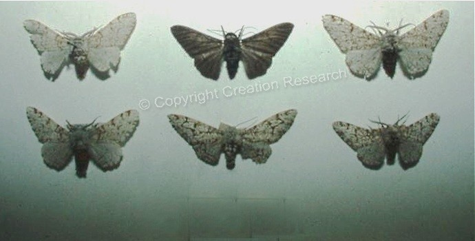

Three alleles, and six different genotypes (CC, CI, CT, II, IT and TT).

Three different phenotypes (black, light colored, mottled).

Allele frequencies: \(p_C\), \(p_I\), \(p_T\) with \(p_C + p_I + p_T = 1.\)

## Peppered Moth

According to *Hardy-Weinberg equilibrium* the genotype frequencies are

\[p_C^2, 2p_Cp_I, 2p_Cp_T, p_I^2, 2p_Ip_T, p_T^2.\]

The complete multinomial log-likelihood is

\[ \begin{aligned} & 2n_{CC} \log(p_C) + n_{CI} \log (2 p_C p_I) + n_{CT} \log(2 p_C p_I) \\ & \ \ + 2 n_{II} \log(p_I) + n_{IT} \log(2p_I p_T) + 2 n_{TT} \log(p_T), \end{aligned} \] We only observe only \((n_C, n_T, n_I)\), where \[n = \underbrace{n_{CC} + n_{CI} + n_{CT}}_{= n_C} + \underbrace{n_{IT} + n_{II}}_{=n_I} + \underbrace{n_{TT}}_{=n_T} \]

## Incomplete data likelihood

Suppose that \(Y\) is a random variable and \(X = M(Y)\). Suppose that \(Y\) has density \(f(\cdot \mid \theta)\) and that \(X\) has marginal density \(g(x \mid \theta)\).

The marginal density is typically of the form \[g(x \mid \theta) = \int_{\{y: M(y) = x\}} f(y \mid \theta) \ \mu_x(\mathrm{d} y)\] for a suitable measure \(\mu_x\) depending on \(M\) and \(x\) but not \(\theta\).

The log-likelihood for observing \(X = x\),

\[\ell(\theta) = \log g(x \mid \theta).\]

## Incomplete data likelihood

The marginal likelihood is often impossible to compute analytically and difficult and expensive to compute numerically.

The complete log-likelihood, \(\log f(y \mid \theta)\), is often easy to compute, but we don't know \(Y\), only that \(M(Y) = x\).

In some cases it is possible to compute

\[Q(\theta \mid \theta') := E_{\theta'}(\log f(Y \mid \theta) \mid X = x),\]

which is the *conditional expectation of the complete log-likelihood given the observed data and under the probability measure given by \(\theta'\).*

## Idea

With an initial guess of \(\theta' = \theta^{(0)}\) compute iteratively \[\theta^{(t + 1)} = \textrm{arg max} \ Q(\theta \mid \theta^{(t)})\] for \(t = 0, 1, 2, \ldots\).

This is the EM-algorithm:

- **E-step**: Compute the conditional expectation \(Q(\theta \mid \theta^{(t)})\).
- **M-step**: Maximize \(\theta \mapsto Q(\theta \mid \theta^{(t)})\).

## The EM-algorithm

For some nice models (e.g. exponential families) the conditional expectation is easy to compute, the complete log-likelihood is easy to maximize, and this transfers to easy maximization of \(Q\).

We prove below that the algorithm is an ascent algorithm; it (weakly) increases the marginal likelihood in every step.

But first some theory about conditional distributions.

## Conditional distributions

It holds in great generality that the conditional distribution of \(Y\) given \(X = x\) has density \[h(y \mid \theta) = \frac{f(y \mid \theta)}{g(x \mid \theta)}\] w.r.t. a suitable measure \(\mu_x\) that does not depend upon \(\theta\).

You can verify this for discrete distributions and when \(Y = (Z, X)\) with joint density w.r.t. a product measure \(\mu \otimes \nu\) that does not depend upon \(\theta\).

## Conditional distributions

In the latter case, \(f(y \mid \theta) = f(z, x \mid \theta)\) and \[g(x \mid \theta) = \int f(z, x \mid \theta) \ \mu(\mathrm{d} z)\] is the marginal density w.r.t. \(\nu\).

In general \[\log g(y \mid \theta) = \log f(y \mid \theta) - \log h(x \mid \theta),\] and under some integrability conditions, this decomposition is used to show that the EM-algorithm increases the likelihood, \(\ell(\theta)\), in each iteration.

## Multinomial cell collapsing

The Peppered Moth example is an example of *cell collapsing* in a multinomial model.

In general, let \(A_1 \cup \ldots \cup A_{K_0} = \{1, \ldots, K\}\) be a partition and let \[M : \mathbb{N}_0^K \to \mathbb{N}_0^{K_0}\] be the map given by \[M((n_1, \ldots, n_K))_j = \sum_{i \in A_j} n_i.\]

## Multinomial cell collapsing

If \(Y \sim \textrm{Mult}(p, n)\) with \(p = (p_1, \ldots, p_K)\) then \[X = M(Y) \sim \textrm{Mult}(M(p), n).\]

For the Peppered Moths, \(K = 6\) corresponding to the six genotypes, \(K_0 = 3\) and the partition corresponding to the phenotypes is \[\{1, 2, 3\} \cup \{4, 5\} \cup \{6\} = \{1, \ldots, 6\},\]

and \[M(n_1, \ldots, n_6) = (n_1 + n_2 + n_3, n_4 + n_5, n_6).\]

## Multinomial cell collapsing

In terms of the \((p_C, p_I)\) parametrization, \(p_T = 1 - p_C - p_I\) and \[p = (p_C^2, 2p_Cp_I, 2p_Cp_T, p_I^2, 2p_Ip_T, p_T^2).\]

Hence \[M(p) = (p_C^2 + 2p_Cp_I + 2p_Cp_T, p_I^2 +2p_Ip_T, p_T^2).\]

The log-likelihood is, \[ \begin{aligned} \ell(p_C, p_I) & = n_C \log(p_C^2 + 2p_Cp_I + 2p_Cp_T) \\ & \ \ \ + n_I \log(p_I^2 +2p_Ip_T) + n_T \log (p_T^2) \end{aligned} \]

## Peppered Moths negative log-likelihood

We can code a problem specific version of the negative log-likelihood and use `optim` to minimize it.

```r
## par = c(pC, pI), pT = 1 - pC - pI
## x is the data vector
loglik <- function(par, x) {
  pT <- 1 - par[1] - par[2]
  if (par[1] > 1 || par[1] < 0 || par[2] > 1 || par[2] < 0 || pT < 0)
    return(Inf)
  PC <- par[1]^2 + 2 * par[1] * par[2] + 2 * par[1] * pT
  PI <- par[2]^2 + 2 * par[2] * pT
  PT <- pT^2
  - (x[1] * log(PC) + x[2] * log(PI) + x[3]* log(PT))
}
```

## Peppered Moths MLE

```r
optim(c(0.3, 0.3), loglik, x = c(85, 196, 341))
```

```
$par
[1] 0.07084643 0.18871900

$value
[1] 600.481

$counts
function gradient
      71       NA

$convergence
[1] 0

$message
NULL
```

## Peppered Moths negative log-likelihood

The computations can beneficially be implemented in greater generality.

```r
M <- function(x, group)
  as.vector(tapply(x, group, sum))
```

## Peppered Moths negative log-likelihood

The function `prob` maps the parameters to the multinomial probability vector. This function will have to be problem specific.

```r
prob <- function(p) {
  p[3] <- 1 - p[1] - p[2]
  c(p[1]^2, 2 * p[1] * p[2], 2* p[1] * p[3],
    p[2]^2, 2 * p[2] * p[3], p[3]^2)
}
```

## Peppered Moths MLE

```r
loglik <- function(par, x) {
  pT <- 1 - par[1] - par[2]
  if (par[1] > 1 || par[1] < 0 || par[2] > 1 || par[2] < 0 || pT < 0)
    return(Inf)
  - sum(x * log(M(prob(par), c(1, 1, 1, 2, 2, 3))))
}
```

## Peppered Moths MLE

```r
optim(c(0.3, 0.3), loglik, x = c(85, 196, 341))
```

```
$par
[1] 0.07084643 0.18871900

$value
[1] 600.481

$counts
function gradient
      71       NA

$convergence
[1] 0

$message
NULL
```

## Peppered Moths summary

- The Peppered Moth example is very simple. The marginal log-likelihood can easily be computed.
- It was used above to illustrate different ways of implementing a likelihood computation in R. One was problem specific and one was more abstract and general.
- Below the example is used to illustrate the EM-algorithm. *The EM-algorithm does not require that we can compute the marginal likelihood.* In (real) applications this will often not be possible.

## Multinomial conditional distributions

The conditional distribution of \(Y_{A_j} = (Y_i)_{i \in A_j}\) conditionally on \(X\) can be found too.

\[Y_{A_j} \mid X = x \sim \textrm{Mult}\left( \frac{p_{A_j}}{M(p)_j}, x_j \right).\]

The probability parameters are simply \(p\) restricted to \(A_j\) and renormalized to a probability vector. Hence

\[E (Y_k \mid X = x) = \frac{x_j p_k}{M(p)_j}\] for \(k \in A_j\).

## General E-step

The EM-algorithm can be implemented by two simple functions that compute the conditional expectations above (the E-step) and then maximization of the complete observation log-likelihood.

```r
EStep0 <- function(p, x, group) {
  pp <- prob(p)
  x[group] * pp / M(pp, group)[group]
}
```

## Generel M-step

The MLE of the complete log-likelihood is a linear estimator, as is the case in many examples with explicit MLEs.

```r
MStep0 <- function(n, X)
  as.vector(X %*% n / (sum(n)))
```

The `EStep0` and `MStep0` functions are abstract implementations. They require specification of the arguments `group` and `X`, respectively, to become concrete.

## Peppered Moths E- and M-steps

Concrete functions for the E- and M-steps are implemented for the particular example.

```r
EStep <- function(p, x)
  EStep0(p, x, c(1, 1, 1, 2, 2, 3))

MStep <- function(n) {
  X <- matrix(
  c(2, 1, 1, 0, 0, 0,
    0, 1, 0, 2, 1, 0) / 2,
  2, 6, byrow = TRUE)
  MStep0(n, X)
}
```

## Peppered Moths EM

```r
EM <- function(par, x, tmax = 10) {
  for(i in 1:tmax)
    par <- MStep(EStep(par, x))
  par  ## Remember to return the parameter estimate
}

phat <- EM(c(0.3, 0.3), c(85, 196, 341))
phat
```

```
[1] 0.07083691 0.18873652
```

## Inside the EM

Check what is going on in each step of the EM-algorithm.

```r
tmp <- matrix(nrow = 20, ncol = 5)
colnames(tmp) <- c("t", "pC", "pI", "R", "loglik")
par <- c(0.3, 0.3)
for(t in 1:20) {
    par0 <- par
    par <- EM(par0, c(85, 196, 341), tmax = 1)
    R <- par - par0
    R <- sqrt(t(R) %*% R / (t(par0) %*% par0))
    tmp[t, ] <- c(t, par[1], par[2], R,
                  loglik(par[-3], c(85, 196, 341)))
}
```

## Inside the EM

```r
head(tmp)
```

```
     t         pC        pI            R   loglik
[1,] 1 0.08038585 0.2246419 0.5472619449 605.7930
[2,] 2 0.07118928 0.1954696 0.1282006840 600.6372
[3,] 3 0.07084985 0.1899339 0.0266600377 600.4859
[4,] 4 0.07083738 0.1889476 0.0048660777 600.4811
[5,] 5 0.07083693 0.1887737 0.0008618753 600.4810
[6,] 6 0.07083691 0.1887430 0.0001517803 600.4810
```

## Inside the EM

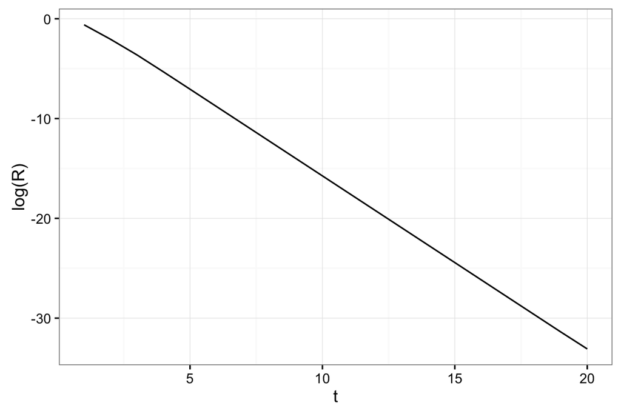

```r
qplot(t, log(R), data = as.data.frame(tmp), geom = "line")
```

Note the log-axis. The EM-algorithm converges rapidly in this example. This is not always the case. If the log-likelihood is flat, the EM-algorithm can become quite slow.